# PYT201 - Analysis and Data Wrangling

#### Data Aggregation

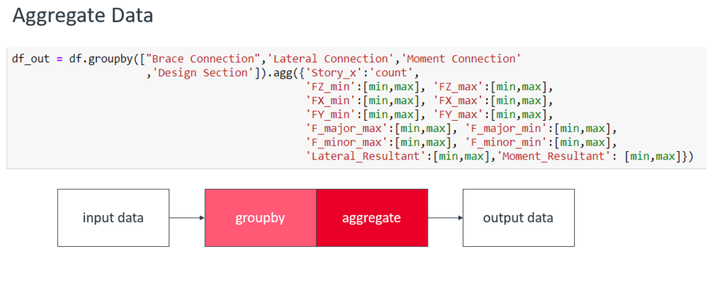

Before we start, I want to change:

- Check to see whether we have any empty rows.
- Change some of the column names

```python
# Let's find out any cells with non entries:
df_quantities.isna()
# This is not very useful.
```

|  | Job Number | Project Name | #WPMIndex | Reference Level | #MaterialGrade | Length | #Concrete Strength | Material Volume | Material Name | Material Area | Id | Name | Category.Name | Symbol.FamilyName |
| --- | --- | --- | --- | --- | --- | --- | --- | --- | --- | --- | --- | --- | --- | --- |
| 0 | False | False | True | True | True | False | True | False | False | False | False | False | False | False |
| 1 | False | False | True | True | True | False | True | False | False | False | False | False | False | False |
| 2 | False | False | True | True | True | False | True | False | False | False | False | False | False | False |
| 3 | False | False | True | True | True | False | True | False | False | False | False | False | False | False |
| 4 | False | False | True | True | True | False | True | False | False | False | False | False | False | False |
| ... | ... | ... | ... | ... | ... | ... | ... | ... | ... | ... | ... | ... | ... | ... |
| 33767 | False | False | False | False | True | False | True | False | False | False | False | False | False | False |
| 33768 | False | False | False | False | True | False | True | False | False | False | False | False | False | False |
| 33769 | False | False | False | False | True | False | True | False | False | False | False | False | False | False |
| 33770 | False | False | False | False | True | False | True | False | False | False | False | False | False | False |
| 33771 | False | False | False | False | True | False | True | False | False | False | False | False | False | False |

33772 rows × 14 columns

Now let's use .all()

.all(axis = 1) : are all the values in axis 1 True? (axis = 1 horizontal-over columns, axis = 0 vertical-over rows)

.any(axis = 1): are any values in axis 1 True?

```python
df_quantities.isna().all(axis=1)
```

```
0        False
1        False
2        False
3        False
4        False
         ...
33767    False
33768    False
33769    False
33770    False
33771    False
Length: 33772, dtype: bool
```

```python
# This is still not very useful
# Let's count the number of empty rows
df_quantities.isna().all(axis=1).value_counts()
```

```
False    33772
dtype: int64
```

```python
# Our dataframe has no empty rows. but if I wanted to filter out the empty rows, I can:
df_quantities = df_quantities[~df_quantities.isna().all(axis=1)]
```

Change column names:

```python
df_quantities.rename(columns={"Symbol.FamilyName":"FamilyName"}, inplace = True)
```

Now let's aggregate to calculate the material quantities for each project. We will aggregate for:

- Job Number
- Material Name

```python
df_quantities.groupby(["Job Number","Material Name"])
```

```
<pandas.core.groupby.generic.DataFrameGroupBy object at 0x000001FEC9B99EC8>
```

```python
df_aggregated_results = df_quantities.groupby(["Job Number","Project Name","Material Name"]).agg({"Material Area":"sum", "Material Volume":"sum"})

df_aggregated_results
```

| Job Number | Project Name | Material Name | Material Area | Material Volume |
| --- | --- | --- | --- | --- |
| M0115005 | Newark Airtrain | #CIP Concrete | 1.355844e+06 | 1.386194e+06 |
|  |  | #Steel - Red | 6.918646e+05 | 3.792606e+04 |
| M0117001 | VCU | #CIP Concrete | 1.686065e+06 | 1.042767e+06 |
|  |  | #CIP Concrete (LinAcc) | 5.436110e+03 | 1.334379e+04 |
|  |  | #CIP Concrete (Solid) | 6.912592e+01 | 5.616996e+00 |
| ... | ... | ... | ... | ... |
| S0118012 | St James | #Steel Deck | 3.395926e+05 | 7.064758e+04 |
|  |  | Concrete - Precast Concrete - Normal Weight - 5 ksi | 4.204285e+04 | 8.113587e+03 |
|  |  | Concrete, Precast | 4.444930e+04 | 5.725183e+03 |
|  |  | Steel ASTM A992 | 1.261223e+03 | 1.772842e+01 |
| S0119006 | LGH | #Steel | 3.187187e+04 | 1.165274e+03 |

68 rows × 2 columns

```python
# Export to excel
df_aggregated_results.to_excel("quantities_version1.xlsx")
```

```python
# I am not too happy with this output.
# Let's clean up this a little bit more
# Generate a dictionary for the transformation.
revit_material_transform = {'#CIP Concrete':'Concrete',
                            '#CIP Concrete(Columns Only)':'Concrete',
                            '#CIP Concrete (Depressed Slab)':'Concrete',
                            '#CIP Concrete(Steel Conc Encasement':'Concrete',
                            '#CIP Concrete(HOUSEKEEPING-PAD)':'Concrete',
                            '#CIP Concrete(Walls)':'Concrete',
                            '#CIP Concrete(Wind)':'Concrete',
                            '#CIP Concrete(ClusterWall)':'Concrete',
                            '#CIP Concrete Elevator Infill':'Concrete',
                            '#CIP Concrete Depression':'Concrete',
                            '#CIP Concrete Infill':'Concrete',
                            '#CIP Concrete (LinAcc)':'Concrete',
                            '#CIP Concrete(Wall)':'Concrete',
                            '#CIP Concrete (Solid)':'Concrete',
                            '#Steel':'Steel',
                            '#Steel - Gray':'Steel',
                            '#Steel - Red':'Steel',
                            '#Steel - Gray Primer':'Steel',
                            '#Masonry - CMU':'CMU',
                            '#PC Concrete':'Precast Concrete',
                            'Concrete - Precast Concrete - Normal Weight - 5 ksi':'Precast Concrete',
                            'Concrete, Precast':'Precast Concrete',
                            '#Steel Deck':'Steel Deck'
                           }
```

```python
df_quantities.replace(revit_material_transform, inplace = True)
```

```python
df_aggregated_results = df_quantities.groupby(["Job Number","Project Name","Material Name"]).agg({"Material Area":"sum", "Material Volume":"sum"})

df_aggregated_results
```

| Job Number | Project Name | Material Name | Material Area | Material Volume |
| --- | --- | --- | --- | --- |
| M0115005 | Newark Airtrain | Concrete | 1.355844e+06 | 1.386194e+06 |
|  |  | Steel | 6.918646e+05 | 3.792606e+04 |
| M0117001 | VCU | #Grating | 2.268297e+02 | 2.362810e+01 |
|  |  | #Metal - Deck (with concrete) | 4.464861e+02 | 0.000000e+00 |
|  |  | CMU | 2.618703e+03 | 4.623873e+03 |
|  |  | Concrete | 1.694204e+06 | 1.057480e+06 |
|  |  | Steel | 1.039059e+06 | 2.665265e+04 |
|  |  | Steel Deck | 1.653763e+04 | 2.067204e+03 |
| M0117002 | Bradley | Concrete | 2.108811e+03 | 5.731713e+02 |
|  |  | Precast Concrete | 4.246746e+05 | 2.258914e+05 |
|  |  | Steel | 3.099628e+02 | 1.477266e+01 |
| M0117003 | Loudoun County Garage | Concrete | 9.924157e+04 | 5.331489e+04 |
|  |  | Precast Concrete | 7.220615e+05 | 2.711235e+05 |
|  |  | Steel | 2.396069e+04 | 4.471278e+02 |
|  |  | Steel Deck | 4.266402e+03 | 5.671507e+02 |
| S0112002 | New Orleans - Roof | Concrete | 1.140999e+05 | 1.041091e+05 |
|  |  | Steel | 3.498780e+05 | 8.148849e+03 |
|  | New Orleans - Structure | #CIP Concrete(Steel Conc Encasement) | 5.831564e+02 | 3.337889e+02 |
|  |  | #Exterior WP Conc Walls | 4.179993e+04 | 5.478470e+04 |
|  |  | #Interior WP Conc Walls | 2.250040e+05 | 2.989894e+05 |
|  |  | #Rigid | 1.373851e+03 | 2.002760e+02 |
|  |  | Concrete | 6.429398e+05 | 4.280767e+05 |
|  |  | Steel | 8.364015e+05 | 1.735435e+04 |
|  |  | Steel Deck | 2.276681e+05 | 2.845850e+04 |
| S0114001 | UVA | #Grating - Gray | 1.612433e+03 | 2.687388e+02 |
|  |  | #Masonry | 3.265714e+03 | 2.064370e+03 |
|  |  | Carbon Steel | 9.001696e+03 | 1.148076e+03 |
|  |  | Concrete | 1.127533e+06 | 7.110078e+05 |
|  |  | Default Roof | 5.616165e+05 | 0.000000e+00 |
|  |  | Steel | 4.849431e+05 | 1.036040e+04 |
| S0117003 | VHC | #Grating | 1.007827e+03 | 8.398558e+01 |
|  |  | Concrete | 3.177252e+05 | 2.065503e+05 |
|  |  | Steel | 3.301679e+05 | 8.273822e+03 |
|  |  | Steel Deck | 1.024294e+04 | 1.707156e+03 |
| S0117009 | ODU | #Grating | 3.990000e+02 | 3.325000e+01 |
|  |  | +07 Insulation - Polyiso | 1.637836e+04 | 4.157259e+03 |
|  |  | Aluminum, anodized finish (non-curtain components) | 2.326650e+05 | 1.384452e+04 |
|  |  | Concrete | 6.774092e+04 | 3.575780e+04 |
|  |  | Precast Concrete | 2.582539e+04 | 2.126726e+04 |
|  |  | Steel | 2.740055e+05 | 5.873391e+03 |
|  |  | Steel Deck | 1.618645e+04 | 2.023306e+03 |
| S0118003 | CFC | Steel | 2.360274e+04 | 4.944551e+02 |
| S0118012 | St James | CMU | 7.174792e+03 | 4.783194e+03 |
|  |  | Concrete | 2.872528e+05 | 1.312983e+05 |
|  |  | Precast Concrete | 3.083397e+05 | 2.349613e+05 |
|  |  | Steel | 3.309659e+05 | 7.733289e+03 |
|  |  | Steel ASTM A992 | 1.261223e+03 | 1.772842e+01 |
|  |  | Steel Deck | 3.395926e+05 | 7.064758e+04 |
| S0119006 | LGH | Steel | 3.187187e+04 | 1.165274e+03 |

```python
# Still not good enough. Let's get rid of the nonstructural materials
revit_material_list = set(revit_material_transform.values())

print(revit_material_list)
```

```
{'Steel', 'Steel Deck', 'CMU', 'Concrete', 'Precast Concrete'}
```

```python
df_quantities['Material Name'].isin(revit_material_list)
```

```
0        True
1        True
2        True
3        True
4        True
         ...
33767    True
33768    True
33769    True
33770    True
33771    True
Name: Material Name, Length: 33772, dtype: bool
```

```python
df_quantities['Material Name'].isin(revit_material_list).value_counts()
```

```
True     33525
False      247
Name: Material Name, dtype: int64
```

```python
df_quantities = df_quantities[df_quantities['Material Name'].isin(revit_material_list)]
```

```python
df_aggregated_results = df_quantities.groupby(["Job Number","Project Name","Material Name"]).agg({"Material Area":"sum", "Material Volume":"sum"})

df_aggregated_results
```

| Job Number | Project Name | Material Name | Material Area | Material Volume |
| --- | --- | --- | --- | --- |
| M0115005 | Newark Airtrain | Concrete | 1.355844e+06 | 1.386194e+06 |
|  |  | Steel | 6.918646e+05 | 3.792606e+04 |
| M0117001 | VCU | CMU | 2.618703e+03 | 4.623873e+03 |
|  |  | Concrete | 1.694204e+06 | 1.057480e+06 |
|  |  | Steel | 1.039059e+06 | 2.665265e+04 |
|  |  | Steel Deck | 1.653763e+04 | 2.067204e+03 |
| M0117002 | Bradley | Concrete | 2.108811e+03 | 5.731713e+02 |
|  |  | Precast Concrete | 4.246746e+05 | 2.258914e+05 |
|  |  | Steel | 3.099628e+02 | 1.477266e+01 |
| M0117003 | Loudoun County Garage | Concrete | 9.924157e+04 | 5.331489e+04 |
|  |  | Precast Concrete | 7.220615e+05 | 2.711235e+05 |
|  |  | Steel | 2.396069e+04 | 4.471278e+02 |
|  |  | Steel Deck | 4.266402e+03 | 5.671507e+02 |
| S0112002 | New Orleans - Roof | Concrete | 1.140999e+05 | 1.041091e+05 |
|  |  | Steel | 3.498780e+05 | 8.148849e+03 |
|  | New Orleans - Structure | Concrete | 6.429398e+05 | 4.280767e+05 |
|  |  | Steel | 8.364015e+05 | 1.735435e+04 |
|  |  | Steel Deck | 2.276681e+05 | 2.845850e+04 |
| S0114001 | UVA | Concrete | 1.127533e+06 | 7.110078e+05 |
|  |  | Steel | 4.849431e+05 | 1.036040e+04 |
| S0117003 | VHC | Concrete | 3.177252e+05 | 2.065503e+05 |
|  |  | Steel | 3.301679e+05 | 8.273822e+03 |
|  |  | Steel Deck | 1.024294e+04 | 1.707156e+03 |
| S0117009 | ODU | Concrete | 6.774092e+04 | 3.575780e+04 |
|  |  | Precast Concrete | 2.582539e+04 | 2.126726e+04 |
|  |  | Steel | 2.740055e+05 | 5.873391e+03 |
|  |  | Steel Deck | 1.618645e+04 | 2.023306e+03 |
| S0118003 | CFC | Steel | 2.360274e+04 | 4.944551e+02 |
| S0118012 | St James | CMU | 7.174792e+03 | 4.783194e+03 |
|  |  | Concrete | 2.872528e+05 | 1.312983e+05 |
|  |  | Precast Concrete | 3.083397e+05 | 2.349613e+05 |
|  |  | Steel | 3.309659e+05 | 7.733289e+03 |
|  |  | Steel Deck | 3.395926e+05 | 7.064758e+04 |
| S0119006 | LGH | Steel | 3.187187e+04 | 1.165274e+03 |

```python
# Export to excel
df_aggregated_results.to_excel("quantities_version2.xlsx")
```

### Merging

```python
df_material_properties = pd.read_excel('material_properties.xlsx')
```

```python
df_material_properties
```

|  | Material | Density |
| --- | --- | --- |
| 0 | NaN | pcf |
| 1 | CMU | 125 |
| 2 | Steel | 490 |
| 3 | Concrete | 150 |
| 4 | Precast Concrete | 150 |
| 5 | Steel Deck | 490 |

```python
df_material_properties = pd.read_excel('material_properties.xlsx', skiprows=[1])
```

```python
df_material_properties
```

|  | Material | Density |
| --- | --- | --- |
| 0 | CMU | 125 |
| 1 | Steel | 490 |
| 2 | Concrete | 150 |
| 3 | Precast Concrete | 150 |
| 4 | Steel Deck | 490 |

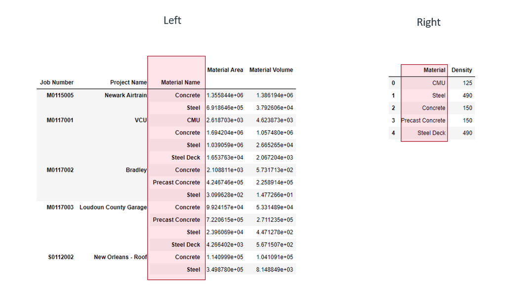

```python
#Let's merge the two dataframes
df_aggregated_results.merge(df_material_properties, how="left", left_on="Material Name", right_on="Material")
```

|  | Material Area | Material Volume | Material | Density |
| --- | --- | --- | --- | --- |
| 0 | 1.355844e+06 | 1.386194e+06 | Concrete | 150 |
| 1 | 6.918646e+05 | 3.792606e+04 | Steel | 490 |
| 2 | 2.618703e+03 | 4.623873e+03 | CMU | 125 |
| 3 | 1.694204e+06 | 1.057480e+06 | Concrete | 150 |
| 4 | 1.039059e+06 | 2.665265e+04 | Steel | 490 |
| 5 | 1.653763e+04 | 2.067204e+03 | Steel Deck | 490 |
| 6 | 2.108811e+03 | 5.731713e+02 | Concrete | 150 |
| 7 | 4.246746e+05 | 2.258914e+05 | Precast Concrete | 150 |
| 8 | 3.099628e+02 | 1.477266e+01 | Steel | 490 |
| 9 | 9.924157e+04 | 5.331489e+04 | Concrete | 150 |
| 10 | 7.220615e+05 | 2.711235e+05 | Precast Concrete | 150 |
| 11 | 2.396069e+04 | 4.471278e+02 | Steel | 490 |
| 12 | 4.266402e+03 | 5.671507e+02 | Steel Deck | 490 |
| 13 | 1.140999e+05 | 1.041091e+05 | Concrete | 150 |
| 14 | 3.498780e+05 | 8.148849e+03 | Steel | 490 |
| 15 | 6.429398e+05 | 4.280767e+05 | Concrete | 150 |
| 16 | 8.364015e+05 | 1.735435e+04 | Steel | 490 |
| 17 | 2.276681e+05 | 2.845850e+04 | Steel Deck | 490 |
| 18 | 1.127533e+06 | 7.110078e+05 | Concrete | 150 |
| 19 | 4.849431e+05 | 1.036040e+04 | Steel | 490 |
| 20 | 3.177252e+05 | 2.065503e+05 | Concrete | 150 |
| 21 | 3.301679e+05 | 8.273822e+03 | Steel | 490 |
| 22 | 1.024294e+04 | 1.707156e+03 | Steel Deck | 490 |
| 23 | 6.774092e+04 | 3.575780e+04 | Concrete | 150 |
| 24 | 2.582539e+04 | 2.126726e+04 | Precast Concrete | 150 |
| 25 | 2.740055e+05 | 5.873391e+03 | Steel | 490 |
| 26 | 1.618645e+04 | 2.023306e+03 | Steel Deck | 490 |
| 27 | 2.360274e+04 | 4.944551e+02 | Steel | 490 |
| 28 | 7.174792e+03 | 4.783194e+03 | CMU | 125 |
| 29 | 2.872528e+05 | 1.312983e+05 | Concrete | 150 |
| 30 | 3.083397e+05 | 2.349613e+05 | Precast Concrete | 150 |
| 31 | 3.309659e+05 | 7.733289e+03 | Steel | 490 |
| 32 | 3.395926e+05 | 7.064758e+04 | Steel Deck | 490 |
| 33 | 3.187187e+04 | 1.165274e+03 | Steel | 490 |

```python
df_aggregated_results
```

| Job Number | Project Name | Material Name | Material Area | Material Volume |
| --- | --- | --- | --- | --- |
| M0115005 | Newark Airtrain | Concrete | 1.355844e+06 | 1.386194e+06 |
|  |  | Steel | 6.918646e+05 | 3.792606e+04 |
| M0117001 | VCU | CMU | 2.618703e+03 | 4.623873e+03 |
|  |  | Concrete | 1.694204e+06 | 1.057480e+06 |
|  |  | Steel | 1.039059e+06 | 2.665265e+04 |
|  |  | Steel Deck | 1.653763e+04 | 2.067204e+03 |
| M0117002 | Bradley | Concrete | 2.108811e+03 | 5.731713e+02 |
|  |  | Precast Concrete | 4.246746e+05 | 2.258914e+05 |
|  |  | Steel | 3.099628e+02 | 1.477266e+01 |
| M0117003 | Loudoun County Garage | Concrete | 9.924157e+04 | 5.331489e+04 |
|  |  | Precast Concrete | 7.220615e+05 | 2.711235e+05 |
|  |  | Steel | 2.396069e+04 | 4.471278e+02 |
|  |  | Steel Deck | 4.266402e+03 | 5.671507e+02 |
| S0112002 | New Orleans - Roof | Concrete | 1.140999e+05 | 1.041091e+05 |
|  |  | Steel | 3.498780e+05 | 8.148849e+03 |
|  | New Orleans - Structure | Concrete | 6.429398e+05 | 4.280767e+05 |
|  |  | Steel | 8.364015e+05 | 1.735435e+04 |
|  |  | Steel Deck | 2.276681e+05 | 2.845850e+04 |
| S0114001 | UVA | Concrete | 1.127533e+06 | 7.110078e+05 |
|  |  | Steel | 4.849431e+05 | 1.036040e+04 |
| S0117003 | VHC | Concrete | 3.177252e+05 | 2.065503e+05 |
|  |  | Steel | 3.301679e+05 | 8.273822e+03 |
|  |  | Steel Deck | 1.024294e+04 | 1.707156e+03 |
| S0117009 | ODU | Concrete | 6.774092e+04 | 3.575780e+04 |
|  |  | Precast Concrete | 2.582539e+04 | 2.126726e+04 |
|  |  | Steel | 2.740055e+05 | 5.873391e+03 |
|  |  | Steel Deck | 1.618645e+04 | 2.023306e+03 |
| S0118003 | CFC | Steel | 2.360274e+04 | 4.944551e+02 |
| S0118012 | St James | CMU | 7.174792e+03 | 4.783194e+03 |
|  |  | Concrete | 2.872528e+05 | 1.312983e+05 |
|  |  | Precast Concrete | 3.083397e+05 | 2.349613e+05 |
|  |  | Steel | 3.309659e+05 | 7.733289e+03 |
|  |  | Steel Deck | 3.395926e+05 | 7.064758e+04 |
| S0119006 | LGH | Steel | 3.187187e+04 | 1.165274e+03 |

```python
df_aggregated_results.reset_index(drop = False, inplace = True)

df_aggregated_results
```

|  | Job Number | Project Name | Material Name | Material Area | Material Volume |
| --- | --- | --- | --- | --- | --- |
| 0 | M0115005 | Newark Airtrain | Concrete | 1.355844e+06 | 1.386194e+06 |
| 1 | M0115005 | Newark Airtrain | Steel | 6.918646e+05 | 3.792606e+04 |
| 2 | M0117001 | VCU | CMU | 2.618703e+03 | 4.623873e+03 |
| 3 | M0117001 | VCU | Concrete | 1.694204e+06 | 1.057480e+06 |
| 4 | M0117001 | VCU | Steel | 1.039059e+06 | 2.665265e+04 |
| 5 | M0117001 | VCU | Steel Deck | 1.653763e+04 | 2.067204e+03 |
| 6 | M0117002 | Bradley | Concrete | 2.108811e+03 | 5.731713e+02 |
| 7 | M0117002 | Bradley | Precast Concrete | 4.246746e+05 | 2.258914e+05 |
| 8 | M0117002 | Bradley | Steel | 3.099628e+02 | 1.477266e+01 |
| 9 | M0117003 | Loudoun County Garage | Concrete | 9.924157e+04 | 5.331489e+04 |
| 10 | M0117003 | Loudoun County Garage | Precast Concrete | 7.220615e+05 | 2.711235e+05 |
| 11 | M0117003 | Loudoun County Garage | Steel | 2.396069e+04 | 4.471278e+02 |
| 12 | M0117003 | Loudoun County Garage | Steel Deck | 4.266402e+03 | 5.671507e+02 |
| 13 | S0112002 | New Orleans - Roof | Concrete | 1.140999e+05 | 1.041091e+05 |
| 14 | S0112002 | New Orleans - Roof | Steel | 3.498780e+05 | 8.148849e+03 |
| 15 | S0112002 | New Orleans - Structure | Concrete | 6.429398e+05 | 4.280767e+05 |
| 16 | S0112002 | New Orleans - Structure | Steel | 8.364015e+05 | 1.735435e+04 |
| 17 | S0112002 | New Orleans - Structure | Steel Deck | 2.276681e+05 | 2.845850e+04 |
| 18 | S0114001 | UVA | Concrete | 1.127533e+06 | 7.110078e+05 |
| 19 | S0114001 | UVA | Steel | 4.849431e+05 | 1.036040e+04 |
| 20 | S0117003 | VHC | Concrete | 3.177252e+05 | 2.065503e+05 |
| 21 | S0117003 | VHC | Steel | 3.301679e+05 | 8.273822e+03 |
| 22 | S0117003 | VHC | Steel Deck | 1.024294e+04 | 1.707156e+03 |
| 23 | S0117009 | ODU | Concrete | 6.774092e+04 | 3.575780e+04 |
| 24 | S0117009 | ODU | Precast Concrete | 2.582539e+04 | 2.126726e+04 |
| 25 | S0117009 | ODU | Steel | 2.740055e+05 | 5.873391e+03 |
| 26 | S0117009 | ODU | Steel Deck | 1.618645e+04 | 2.023306e+03 |
| 27 | S0118003 | CFC | Steel | 2.360274e+04 | 4.944551e+02 |
| 28 | S0118012 | St James | CMU | 7.174792e+03 | 4.783194e+03 |
| 29 | S0118012 | St James | Concrete | 2.872528e+05 | 1.312983e+05 |
| 30 | S0118012 | St James | Precast Concrete | 3.083397e+05 | 2.349613e+05 |
| 31 | S0118012 | St James | Steel | 3.309659e+05 | 7.733289e+03 |
| 32 | S0118012 | St James | Steel Deck | 3.395926e+05 | 7.064758e+04 |
| 33 | S0119006 | LGH | Steel | 3.187187e+04 | 1.165274e+03 |

```python
#Let's merge the two dataframes
df_merged_results = df_aggregated_results.merge(df_material_properties, how="left", left_on="Material Name", right_on="Material")

df_merged_results
```

|  | Job Number | Project Name | Material Name | Material Area | Material Volume | Material | Density |
| --- | --- | --- | --- | --- | --- | --- | --- |
| 0 | M0115005 | Newark Airtrain | Concrete | 1.355844e+06 | 1.386194e+06 | Concrete | 150 |
| 1 | M0115005 | Newark Airtrain | Steel | 6.918646e+05 | 3.792606e+04 | Steel | 490 |
| 2 | M0117001 | VCU | CMU | 2.618703e+03 | 4.623873e+03 | CMU | 125 |
| 3 | M0117001 | VCU | Concrete | 1.694204e+06 | 1.057480e+06 | Concrete | 150 |
| 4 | M0117001 | VCU | Steel | 1.039059e+06 | 2.665265e+04 | Steel | 490 |
| 5 | M0117001 | VCU | Steel Deck | 1.653763e+04 | 2.067204e+03 | Steel Deck | 490 |
| 6 | M0117002 | Bradley | Concrete | 2.108811e+03 | 5.731713e+02 | Concrete | 150 |
| 7 | M0117002 | Bradley | Precast Concrete | 4.246746e+05 | 2.258914e+05 | Precast Concrete | 150 |
| 8 | M0117002 | Bradley | Steel | 3.099628e+02 | 1.477266e+01 | Steel | 490 |
| 9 | M0117003 | Loudoun County Garage | Concrete | 9.924157e+04 | 5.331489e+04 | Concrete | 150 |
| 10 | M0117003 | Loudoun County Garage | Precast Concrete | 7.220615e+05 | 2.711235e+05 | Precast Concrete | 150 |
| 11 | M0117003 | Loudoun County Garage | Steel | 2.396069e+04 | 4.471278e+02 | Steel | 490 |
| 12 | M0117003 | Loudoun County Garage | Steel Deck | 4.266402e+03 | 5.671507e+02 | Steel Deck | 490 |
| 13 | S0112002 | New Orleans - Roof | Concrete | 1.140999e+05 | 1.041091e+05 | Concrete | 150 |
| 14 | S0112002 | New Orleans - Roof | Steel | 3.498780e+05 | 8.148849e+03 | Steel | 490 |
| 15 | S0112002 | New Orleans - Structure | Concrete | 6.429398e+05 | 4.280767e+05 | Concrete | 150 |
| 16 | S0112002 | New Orleans - Structure | Steel | 8.364015e+05 | 1.735435e+04 | Steel | 490 |
| 17 | S0112002 | New Orleans - Structure | Steel Deck | 2.276681e+05 | 2.845850e+04 | Steel Deck | 490 |
| 18 | S0114001 | UVA | Concrete | 1.127533e+06 | 7.110078e+05 | Concrete | 150 |
| 19 | S0114001 | UVA | Steel | 4.849431e+05 | 1.036040e+04 | Steel | 490 |
| 20 | S0117003 | VHC | Concrete | 3.177252e+05 | 2.065503e+05 | Concrete | 150 |
| 21 | S0117003 | VHC | Steel | 3.301679e+05 | 8.273822e+03 | Steel | 490 |
| 22 | S0117003 | VHC | Steel Deck | 1.024294e+04 | 1.707156e+03 | Steel Deck | 490 |
| 23 | S0117009 | ODU | Concrete | 6.774092e+04 | 3.575780e+04 | Concrete | 150 |
| 24 | S0117009 | ODU | Precast Concrete | 2.582539e+04 | 2.126726e+04 | Precast Concrete | 150 |
| 25 | S0117009 | ODU | Steel | 2.740055e+05 | 5.873391e+03 | Steel | 490 |
| 26 | S0117009 | ODU | Steel Deck | 1.618645e+04 | 2.023306e+03 | Steel Deck | 490 |
| 27 | S0118003 | CFC | Steel | 2.360274e+04 | 4.944551e+02 | Steel | 490 |
| 28 | S0118012 | St James | CMU | 7.174792e+03 | 4.783194e+03 | CMU | 125 |
| 29 | S0118012 | St James | Concrete | 2.872528e+05 | 1.312983e+05 | Concrete | 150 |
| 30 | S0118012 | St James | Precast Concrete | 3.083397e+05 | 2.349613e+05 | Precast Concrete | 150 |
| 31 | S0118012 | St James | Steel | 3.309659e+05 | 7.733289e+03 | Steel | 490 |
| 32 | S0118012 | St James | Steel Deck | 3.395926e+05 | 7.064758e+04 | Steel Deck | 490 |
| 33 | S0119006 | LGH | Steel | 3.187187e+04 | 1.165274e+03 | Steel | 490 |

### Lambda

Calculate weight (tonnage)

```python
df_merged_results['Tonnage']=df_merged_results.apply(lambda x: x['Material Volume']*x['Density']*0.0005, axis = 1)
```

```python
df_merged_results
```

|  | Job Number | Project Name | Material Name | Material Area | Material Volume | Material | Density | Tonnage |
| --- | --- | --- | --- | --- | --- | --- | --- | --- |
| 0 | M0115005 | Newark Airtrain | Concrete | 1.355844e+06 | 1.386194e+06 | Concrete | 150 | 103964.530563 |
| 1 | M0115005 | Newark Airtrain | Steel | 6.918646e+05 | 3.792606e+04 | Steel | 490 | 9291.884934 |
| 2 | M0117001 | VCU | CMU | 2.618703e+03 | 4.623873e+03 | CMU | 125 | 288.992047 |
| 3 | M0117001 | VCU | Concrete | 1.694204e+06 | 1.057480e+06 | Concrete | 150 | 79310.980199 |
| 4 | M0117001 | VCU | Steel | 1.039059e+06 | 2.665265e+04 | Steel | 490 | 6529.899088 |
| 5 | M0117001 | VCU | Steel Deck | 1.653763e+04 | 2.067204e+03 | Steel Deck | 490 | 506.464985 |
| 6 | M0117002 | Bradley | Concrete | 2.108811e+03 | 5.731713e+02 | Concrete | 150 | 42.987845 |
| 7 | M0117002 | Bradley | Precast Concrete | 4.246746e+05 | 2.258914e+05 | Precast Concrete | 150 | 16941.858047 |
| 8 | M0117002 | Bradley | Steel | 3.099628e+02 | 1.477266e+01 | Steel | 490 | 3.619302 |
| 9 | M0117003 | Loudoun County Garage | Concrete | 9.924157e+04 | 5.331489e+04 | Concrete | 150 | 3998.616541 |
| 10 | M0117003 | Loudoun County Garage | Precast Concrete | 7.220615e+05 | 2.711235e+05 | Precast Concrete | 150 | 20334.259167 |
| 11 | M0117003 | Loudoun County Garage | Steel | 2.396069e+04 | 4.471278e+02 | Steel | 490 | 109.546311 |
| 12 | M0117003 | Loudoun County Garage | Steel Deck | 4.266402e+03 | 5.671507e+02 | Steel Deck | 490 | 138.951928 |
| 13 | S0112002 | New Orleans - Roof | Concrete | 1.140999e+05 | 1.041091e+05 | Concrete | 150 | 7808.182708 |
| 14 | S0112002 | New Orleans - Roof | Steel | 3.498780e+05 | 8.148849e+03 | Steel | 490 | 1996.468121 |
| 15 | S0112002 | New Orleans - Structure | Concrete | 6.429398e+05 | 4.280767e+05 | Concrete | 150 | 32105.753571 |
| 16 | S0112002 | New Orleans - Structure | Steel | 8.364015e+05 | 1.735435e+04 | Steel | 490 | 4251.815140 |
| 17 | S0112002 | New Orleans - Structure | Steel Deck | 2.276681e+05 | 2.845850e+04 | Steel Deck | 490 | 6972.332161 |
| 18 | S0114001 | UVA | Concrete | 1.127533e+06 | 7.110078e+05 | Concrete | 150 | 53325.584638 |
| 19 | S0114001 | UVA | Steel | 4.849431e+05 | 1.036040e+04 | Steel | 490 | 2538.297398 |
| 20 | S0117003 | VHC | Concrete | 3.177252e+05 | 2.065503e+05 | Concrete | 150 | 15491.275601 |
| 21 | S0117003 | VHC | Steel | 3.301679e+05 | 8.273822e+03 | Steel | 490 | 2027.086353 |
| 22 | S0117003 | VHC | Steel Deck | 1.024294e+04 | 1.707156e+03 | Steel Deck | 490 | 418.253269 |
| 23 | S0117009 | ODU | Concrete | 6.774092e+04 | 3.575780e+04 | Concrete | 150 | 2681.835076 |
| 24 | S0117009 | ODU | Precast Concrete | 2.582539e+04 | 2.126726e+04 | Precast Concrete | 150 | 1595.044562 |
| 25 | S0117009 | ODU | Steel | 2.740055e+05 | 5.873391e+03 | Steel | 490 | 1438.980698 |
| 26 | S0117009 | ODU | Steel Deck | 1.618645e+04 | 2.023306e+03 | Steel Deck | 490 | 495.710074 |
| 27 | S0118003 | CFC | Steel | 2.360274e+04 | 4.944551e+02 | Steel | 490 | 121.141507 |
| 28 | S0118012 | St James | CMU | 7.174792e+03 | 4.783194e+03 | CMU | 125 | 298.949653 |
| 29 | S0118012 | St James | Concrete | 2.872528e+05 | 1.312983e+05 | Concrete | 150 | 9847.370246 |
| 30 | S0118012 | St James | Precast Concrete | 3.083397e+05 | 2.349613e+05 | Precast Concrete | 150 | 17622.097406 |
| 31 | S0118012 | St James | Steel | 3.309659e+05 | 7.733289e+03 | Steel | 490 | 1894.655915 |
| 32 | S0118012 | St James | Steel Deck | 3.395926e+05 | 7.064758e+04 | Steel Deck | 490 | 17308.657341 |
| 33 | S0119006 | LGH | Steel | 3.187187e+04 | 1.165274e+03 | Steel | 490 | 285.492072 |

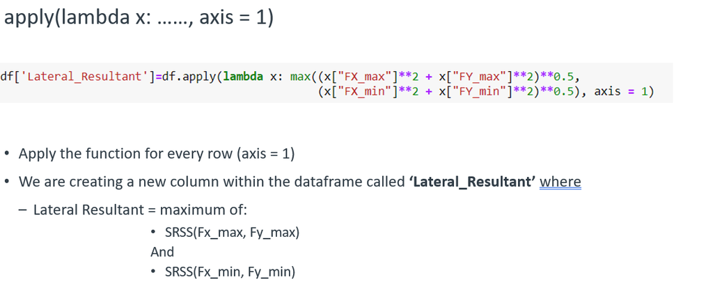